# 04 · Automatización masiva y ejecución programada

## Automatización masiva de documentos

[figure not shown]

04 · LOTES Y EJECUCIÓN PROGRAMADA EN WINDOWS, MACOS Y LINUX

Automatización masiva  
de documentos

**Windows Task Scheduler, launchd, cron y systemd**

Caso conductor: observatorio territorial de deuda tributaria publicada.

Datos de aula completamente ficticios.

## De una operación a un lote con resultado verificable

En el bloque 03 dominamos rutas y cambios individuales. Un lote añade selección, una decisión por elemento y una reconciliación del conjunto.

La programación temporal añade otro contrato: qué ejecutable arranca, con qué argumentos, cuenta, contexto y política de repetición.

**Objetivo**

Procesar documentos sintéticos y saber qué pasó aunque nadie esté mirando una terminal.

El calendario inicia el trabajo. La aplicación informa del resultado.

## Tres piezas que deben encajar

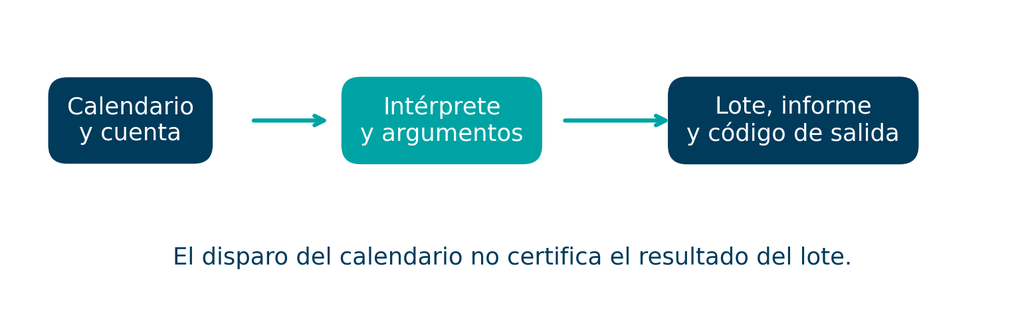

El mismo programa puede ejecutarse manualmente, con Windows Task Scheduler, con launchd o mediante cron o systemd. Sus rutas y códigos de salida deben conservar significado en todos los casos.

## Alcance y relación con el resto del curso

| En este bloque | Se desarrollará después |
| --- | --- |
| Procesamiento por lotes y documentos de texto con plantilla. | Excel, PDF e informes especializados. |
| CLI, configuración, registros, bloqueo y repetición. | Integraciones por API, web y correo. |
| Programación nativa en tres sistemas. | Agentes e IA para otros tipos de decisión. |
| Operación local con datos sintéticos. | Copias de seguridad y restauración en el bloque 05. |

## El contrato del lote comienza en la selección

Se seleccionan archivos JSON regulares, hijos directos de entrada. Se excluyen enlaces y otros sufijos. El orden se fija por nombre.

La entrada no se modifica ni se mueve al terminar. Una salida no vuelve a entrar en la selección.

**Frontera de aula**

Cinco JSON seleccionados. Un TXT ignorado por contrato. Una plantilla validada. Carpetas de entrada, salida, informes y estado separadas.

## Un error por elemento y un error global requieren respuestas distintas

| Situación | Nivel | Respuesta |
| --- | --- | --- |
| Un JSON incompleto. | Elemento. | Registrar inválido y seguir con los demás. |
| Falta un campo obligatorio. | Elemento. | Registrar motivo sin inventar un dato. |
| Plantilla incompatible. | Global. | Detener antes de generar documentos. |
| No se puede escribir una salida. | Operativo global. | Terminar con fallo y revisar posibles resultados parciales. |

No se capturan indiscriminadamente todos los fallos como si fueran documentos inválidos.

## La plantilla convierte datos validados en un documento

```
# Informe de aula ${id}

Año: ${anio}
Importe: ${importe} EUR
Territorio ficticio: ${territorio}
Motor: ${version}
```

Utilizamos `string.Template`. Exigimos los cinco campos acordados y validamos la plantilla antes de empezar el lote.

El documento no incorpora la hora de ejecución: con la misma entrada, plantilla y versión, su contenido debe mantenerse estable.

## Estados por documento y salida reconciliada

| Estado | Qué significa |
| --- | --- |
| Previsto | En simulación, se crearía una salida nueva. |
| Creado | Se terminó una creación exclusiva. |
| Omitido | Ya existe exactamente el mismo contenido. |
| Inválido | La entrada incumple el contrato. |
| Duplicado | Una clave de salida se repite dentro del lote. |
| Conflicto | Existe un destino con contenido diferente. |

## Reconciliar obliga a explicar cada elemento

$$N_{seleccionados}=N_{creados}+N_{omitidos}+N_{invalidos}+N_{duplicados}+N_{conflictos}$$

En simulación se sustituye el estado creado por previsto. Cada entrada seleccionada tiene un único estado principal en una ejecución completada.

Si ocurre un fallo operativo global, puede no existir un informe final completo. Se revisan los registros y las salidas que hayan quedado; no se afirma éxito por haber generado algunos archivos.

## La repetición conserva documentos, pero genera nueva evidencia

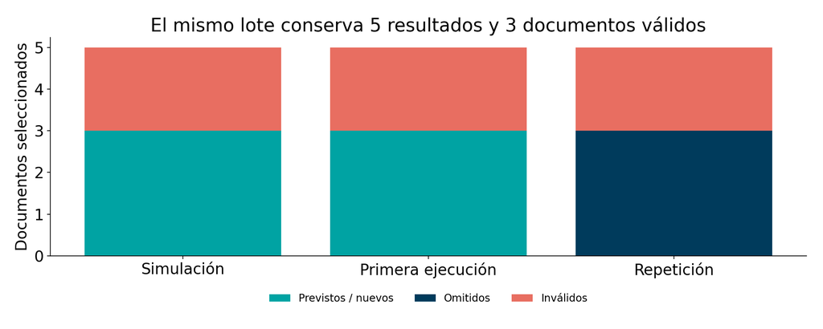

Primera ejecución: tres creados y dos inválidos. Repetición: tres omitidos y dos inválidos. Los documentos válidos no se duplican; cada ejecución real genera otro informe operativo.

## El programa necesita una interfaz no interactiva

```
python procesar_lote.py --config RUTA_CONFIG --simular
python procesar_lote.py --config RUTA_CONFIG
```

El primer comando previsualiza sin crear documentos, informes ni bloqueo. El segundo ejecuta. La configuración se resuelve desde su propia carpeta y no desde el directorio de trabajo.

Los parámetros deben poder proporcionarse sin ventanas, preguntas ni `input()`.

## La configuración separa rutas y lógica

```json
{
  "version": 1,
  "entrada": "entrada",
  "salida": "salida",
  "informes": "informes",
  "estado": "estado",
  "plantilla": "plantillas/documento.txt"
}
```

Las rutas internas son relativas a la carpeta de `config.json`. Se validan pertenencia, ausencia de enlaces y separación de carpetas de trabajo.

## Códigos de salida: el contrato con el sistema operativo

| Código | Significado del ejemplo |
| --- | --- |
| 0 | Lote terminado sin incidencias de contenido. |
| 10 | Lote terminado con inválidos, duplicados o conflictos. |
| 20 | Configuración o dependencia de configuración incompatible. |
| 30 | Fallo operativo o inesperado; puede haber salida parcial. |
| 40 | Existe un bloqueo de ejecución. |
| 2 | Argumentos incorrectos, gestionados por argparse. |

## stdout, stderr y el informe cumplen funciones diferentes

`stdout` entrega el resumen estructurado del programa. `stderr` conserva mensajes de ejecución y errores. El informe JSON permite revisar estados y motivos de un lote completado.

Si falla antes de generar el informe, los registros de lanzamiento siguen siendo necesarios.

**Trazabilidad útil**

Versión del motor, intérprete, directorio, PID y momentos de ejecución.

Nombres de archivo y estados del lote.

Sin registrar credenciales ni copiar datos personales innecesarios.

## Un bloqueo evita dos escritores cooperantes

```python
os.open(ruta_bloqueo,
    os.O_WRONLY | os.O_CREAT | os.O_EXCL,
    0o600)
```

La creación exclusiva del archivo decide quién obtiene el bloqueo en el proyecto local. La ejecución guarda token, PID y hora.

El bloqueo se retira al finalizar normalmente. Una terminación forzada puede dejarlo huérfano. No se borra automáticamente por ser antiguo.

## Frecuencia, duración y solapamiento

$$D>T\ \Longrightarrow\ \text{puede haber otra activacion antes de terminar}$$

$D$: duración de una ejecución. $T$: separación entre activaciones. Incluso con $D<T$, una incidencia o ejecución manual puede provocar solapamiento.

Debemos decidir entre ignorar una activación, ponerla en cola o ejecutar en paralelo. La práctica usa una sola ejecución activa; la cola de trabajo real exigiría otro diseño.

## Antes de programar, demostrar la ejecución manual

1. Crear entorno virtual y datos sintéticos.
2. Ejecutar la simulación con rutas absolutas.
3. Ejecutar el lote y revisar el código y los documentos.
4. Repetir y comprobar omitidos.
5. Probar desde otra carpeta y revisar registros.

La demo incluye dos inválidos a propósito: el código 10 es esperado hasta corregirlos. No registres una tarea pensando que ese resultado equivale a un éxito sin incidencias.

## Crear el entorno virtual no exige activarlo para programar

```
py -3.11 -m venv .venv
.venv\Scripts\python.exe --version

# Linux o macOS:
python3 -m venv .venv
.venv/bin/python --version
```

Para la tarea se invoca directamente ese intérprete con ruta absoluta. No se depende de la activación de una terminal ni del primer `python` que aparezca en PATH.

## Por qué funciona en terminal y falla al programar

[figure not shown]

El contexto programado puede ser distinto: variables, carpetas, sesión, permisos y recursos de red. Diagnosticarlo exige observar el contexto real, no repetir la misma orden suponiendo que todo sigue igual.

## Mapa de herramientas de ejecución

| Necesidad | Windows | macOS | Linux |
| --- | --- | --- | --- |
| Calendario nativo | Task Scheduler. | launchd. | cron o systemd.timer. |
| Lanzador con parámetros | PowerShell o .bat. | Script shell o argumentos del plist. | Script shell o ExecStart. |
| Ensayo puntual | Tarea de una vez / ejecución manual. | kickstart de la tarea preparada. | at o inicio manual del servicio. |
| Proceso residente | Servicio de Windows. | Daemon o agente supervisado. | Servicio systemd. |

## Windows Task Scheduler: tarea, desencadenador y acción

Una tarea combina un calendario o evento, una acción, una cuenta y condiciones de ejecución. La configuración permanece registrada aunque cierres la ventana del programador.

Se abre con **Win + R → taskschd.msc**. Para aprender los campos utilizaremos «Crear tarea», que expone más opciones que el asistente básico.

La tarea de clase tendrá un nombre reconocible: `CursoAuto_Bloque04_Demo`. No se sustituye ninguna tarea existente automáticamente.

## Pestaña General: la cuenta forma parte del contrato

| Campo | Decisión de aula |
| --- | --- |
| Nombre | CursoAuto_Bloque04_Demo. |
| Usuario | La cuenta que tiene acceso al proyecto. |
| Inicio de sesión | Primero, ejecutar solo con sesión iniciada. |
| Privilegios elevados | No activarlos por rutina. |
| Descripción | Datos sintéticos, rutas y finalidad reconocibles. |

La cuenta debe tener acceso a Python, configuración, entrada, salida y registros.

## Sesión iniciada, sesión cerrada y recursos de red

«Ejecutar tanto si el usuario inició sesión como si no» cambia el contexto de autenticación y puede requerir credenciales o permisos específicos.

Las unidades de red mapeadas en una sesión interactiva pueden no estar disponibles en la tarea.

**Aplicación al proyecto**

Una unidad local y una unidad de red mapeada no son equivalentes.

Para un recurso compartido, revisa ruta UNC, identidad y autorización de esa cuenta. Nunca asumas que ve lo mismo que tu explorador.

## Desencadenadores: cuándo se solicita una ejecución

| Ejemplo | Qué representa |
| --- | --- |
| Una vez | Ensayo en un momento concreto. |
| Diariamente a las 09:00 | Calendario local del ejemplo. |
| Al iniciar sesión | Depende del acceso de esa cuenta. |
| Al iniciar el equipo | Arranque del sistema y condiciones de cuenta. |
| Por un evento | Un evento definido dispara la tarea. |

La hora del desencadenador no garantiza que el trabajo termine a esa hora.

## Acción: tres campos que no deben mezclarse

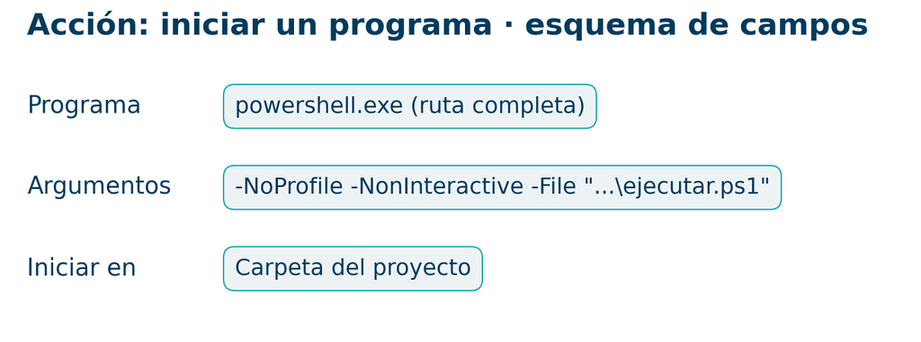

Se entrega un wrapper PowerShell que localiza el proyecto, invoca el Python del entorno virtual, espera su terminación y devuelve su código. El esquema es orientativo, no una captura de una versión concreta.

## Acción concreta con el wrapper del paquete

| Campo | Ejemplo que debe adaptarse |
| --- | --- |
| Programa | Ruta completa a WindowsPowerShell/v1.0/powershell.exe. |
| Argumentos | `-NoProfile -NonInteractive -File "C:\CursoAuto\bloque04\programacion\windows\ejecutar.ps1"` |
| Iniciar en | `C:\CursoAuto\bloque04` |

Las rutas con espacios se delimitan en los argumentos. El wrapper calcula su base desde su propia ubicación dentro del paquete.

## Una invocación directa de Python también es posible

```
Programa: C:\CursoAuto\bloque04\.venv\Scripts\python.exe
Argumentos: -u "C:\CursoAuto\bloque04\procesar_lote.py"
            --config "C:\CursoAuto\bloque04\trabajo_demo\config.json"
Iniciar en: C:\CursoAuto\bloque04
```

El ejemplo de argumentos se muestra partido para leerlo; en el campo del programador es una única cadena. Windows Task Scheduler no redirige automáticamente stdout y stderr a tus archivos.

## Condiciones: energía, inactividad y disponibilidad

Una tarea puede quedar pendiente por condiciones de batería, inactividad o red. El equipo apagado no ejecuta Python; despertar un equipo suspendido requiere soporte y una configuración concreta.

Revisa las condiciones según el objetivo del ensayo, no desactives todo para hacer desaparecer un síntoma.

**Ejemplo de diagnóstico**

La tarea tiene hora correcta, pero solo se permite con alimentación de corriente.

En un portátil con batería puede no iniciarse. Ese resultado no demuestra un error del código Python.

## Configuración: ejecución perdida, duración e instancias

| Opción | Criterio del ejemplo |
| --- | --- |
| Ejecutar al estar disponible tras perder una hora. | StartWhenAvailable, con límites del programador. |
| Tarea ya activa. | No iniciar una instancia nueva. |
| Límite de duración. | Diez minutos como ejemplo, no un valor universal. |
| Reinicio tras fallo. | No se activa por defecto para incidencias permanentes. |

Una terminación forzada puede dejar archivos parciales o un bloqueo que requiera revisión.

## PowerShell prepara una acción con contexto explícito

```powershell
$Action = New-ScheduledTaskAction `
  -Execute $PowerShellExe `
  -Argument ('-NoProfile -NonInteractive -File "{0}"' -f $Wrapper) `
  -WorkingDirectory $ProjectDir
```

`-NoProfile` evita depender del perfil interactivo. `-NonInteractive` hace visible una necesidad inesperada de interacción. Los parámetros no corrigen por sí solos permisos o rutas inválidas.

## PowerShell define calendario y políticas por separado

```powershell
$Trigger = New-ScheduledTaskTrigger -Daily -At "09:00"
$Settings = New-ScheduledTaskSettingsSet `
  -MultipleInstances IgnoreNew -StartWhenAvailable `
  -ExecutionTimeLimit (New-TimeSpan -Minutes 10)
$Principal = New-ScheduledTaskPrincipal `
  -UserId $Account -LogonType Interactive -RunLevel Limited
```

La cuenta del ejemplo necesita sesión iniciada. No almacena contraseñas y no utiliza SYSTEM.

## Registro deliberado, consulta y ensayo

```powershell
.\programacion\windows\registrar_tarea.ps1
# Solo muestra la vista previa.

.\programacion\windows\registrar_tarea.ps1 -Registrar
Get-ScheduledTask -TaskName CursoAuto_Bloque04_Demo
Get-ScheduledTaskInfo -TaskName CursoAuto_Bloque04_Demo
Start-ScheduledTask -TaskName CursoAuto_Bloque04_Demo
```

Los comandos se ejecutan solo después de preparar y comprobar la demo en tu equipo. `Start-ScheduledTask` solicita el inicio; revisa después el estado, los registros y el resultado real.

## El wrapper PowerShell espera y conserva el código del hijo

```powershell
$Child = Start-Process -FilePath $PythonExe `
  -ArgumentList $PythonArgs -WorkingDirectory $ProjectDir `
  -Wait -PassThru -NoNewWindow `
  -RedirectStandardOutput $OutLog `
  -RedirectStandardError $ErrLog
exit $Child.ExitCode
```

Cada ejecución genera nombres de registro únicos. `Start-Process` debe recibir argumentos con el entrecomillado correcto, porque une su lista para construir la línea de comandos.

## El wrapper .bat es una alternativa sencilla

```
"%PYTHON_EXE%" -u "%PROJECT_DIR%\procesar_lote.py" ^
  --config "%CONFIG_FILE%" >> "%OUT_LOG%" 2>> "%ERR_LOG%"
set "RESULTADO=%ERRORLEVEL%"
exit /b %RESULTADO%
```

El archivo entregado calcula rutas desde `%~dp0`, utiliza `cd /d` y comprueba Python y configuración. Los nombres OUT_LOG y ERR_LOG de este fragmento representan las rutas completas incluidas en el archivo.

## schtasks permite consultar, ejecutar e intercambiar XML

```
schtasks /Query /TN "CursoAuto_Bloque04_Demo" /V /FO LIST
schtasks /Run /TN "CursoAuto_Bloque04_Demo"
schtasks /Query /TN "CursoAuto_Bloque04_Demo" /XML

# En otro ensayo, con un XML revisado:
schtasks /Create /TN "CursoAuto_Bloque04_Importada" /XML "tarea.xml"
```

Exportar conserva definición, no todos los requisitos del equipo de destino. Revisa cuenta, permisos, ejecutables y rutas al importar.

## Historial y códigos: cómo leer un resultado

Consulta estado, última hora de ejecución, próximo inicio y resultado de la acción. Habilita el historial si está disponible y permitido por tu configuración.

En la aplicación, 10 decimal es **0xA**, 20 es **0x14**, 30 es **0x1E** y 40 es **0x28**.

**Interpretación**

0xA en el ejemplo indica documentos con incidencias.

No significa universalmente lo mismo en otros programas.

Un código propio de Task Scheduler antes de lanzar Python exige investigar otra capa.

## Diagnóstico de Windows por capas

| Síntoma | Primera comprobación |
| --- | --- |
| No llega a arrancar Python. | Acción, cuenta, condiciones y política de scripts. |
| No encuentra paquetes o usa otra versión. | Ruta completa de sys.executable y del entorno. |
| No encuentra la configuración. | Argumento absoluto y estructura del proyecto. |
| No puede acceder a una carpeta de red. | Identidad y acceso real de la cuenta. |
| Lote con código 10. | Informe de elementos, no reinstalar Python. |
| Código 40. | Otra ejecución o bloqueo pendiente de revisión. |

## Política de ejecución y administración del equipo

Si PowerShell bloquea un archivo, consulta la política aplicable y la procedencia del script. En un equipo corporativo puede haber una política administrada que no puedes ni debes reemplazar desde la práctica.

Revisa el archivo antes de desbloquearlo de forma individual cuando corresponda.

**Criterio del material**

No utiliza Bypass de forma predeterminada, no cambia la política de toda la máquina y no guarda contraseñas.

La cuenta recibe los accesos necesarios para el trabajo definido.

## Retirar la tarea de clase de forma explícita

```powershell
Disable-ScheduledTask -TaskName CursoAuto_Bloque04_Demo

# Cuando ya no se necesite, revisar y retirar:
Unregister-ScheduledTask -TaskName CursoAuto_Bloque04_Demo
```

Deshabilitar evita nuevas activaciones; no equivale a revisar una ejecución que ya está activa. Retirar la definición no elimina necesariamente documentos ni registros generados.

La limpieza se limita al nombre de tarea de clase que has creado.

## Servicios Windows: un ciclo de vida diferente

Un servicio se integra con el administrador de servicios de Windows y debe responder a su contrato de inicio, estado y parada. Un script Python ordinario que termina tras procesar un lote no implementa automáticamente ese contrato.

**Elección del mecanismo**

Para un lote diario que arranca y termina, Task Scheduler es el mecanismo que practicamos. Un proceso residente requiere una implementación de servicio o un supervisor adecuado, además de sus políticas de recuperación.

[Microsoft · Service Entry Point](https://learn.microsoft.com/en-us/windows/win32/services/service-entry-point).

## Power Automate Desktop añade sesión e interacción de escritorio

Cuando el proceso necesita interactuar con aplicaciones de escritorio, una plataforma de automatización puede gestionar acciones y contexto de sesión. Eso añade requisitos de máquina, identidad, disponibilidad y gobierno que deben evaluarse.

La documentación de Power Automate distingue ejecución atendida y desatendida. Las capacidades de programación y sus condiciones deben comprobarse para la versión y el entorno de la organización.

En el caso del curso, Python ya puede leer entradas y producir documentos sin una interfaz gráfica. No añadimos automatización de escritorio para ejecutar ese mismo contrato.

[Microsoft · Ejecución desatendida de flujos de escritorio](https://learn.microsoft.com/en-us/power-automate/desktop-flows/run-unattended-desktop-flows).

## Linux: cron y systemd.timer ofrecen contratos diferentes

| Herramienta | Fortalezas | Qué revisar |
| --- | --- | --- |
| cron | Calendarios sencillos y crontab por usuario. | Entorno reducido, salidas y activaciones perdidas. |
| systemd.timer | Servicio separado, estado y registros integrados. | Gestor disponible y alcance de usuario o sistema. |
| at | Ejecución puntual diferida. | Servicio instalado, cuenta y entorno. |
| anacron | Tareas periódicas en equipos no siempre activos. | Intervalo y retraso; no hora exacta universal. |

## Los cinco campos de una crontab de usuario

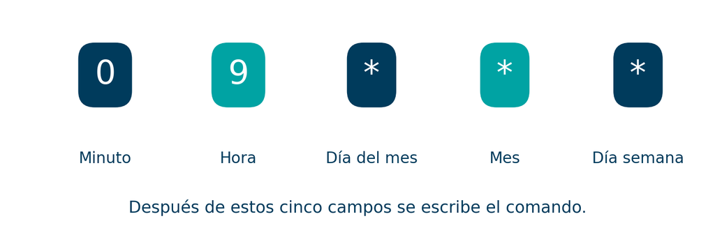

`0 9 * * *` solicita una ejecución diaria a las 09:00. Después va el comando. La crontab de usuario no incluye una columna adicional con el nombre de cuenta.

## Patrones frecuentes y un caso que suele confundirse

| Patrón | Interpretación habitual en cron compatible |
| --- | --- |
| `*/15 * * * *` | Cada 15 minutos. |
| `0 9 * * 1-5` | Lunes a viernes a las 09:00. |
| `0 9 1 * *` | Primer día de cada mes a las 09:00. |
| `0 9 1 * 1` | En implementaciones como Cronie: día 1 o lunes. |

Cuando se restringen día de mes y día de semana, la combinación puede ser OR, no el AND que se imagina intuitivamente.

## Cron ejecuta en un entorno reducido

```
SHELL=/bin/sh
PATH=/usr/bin:/bin
MAILTO=""
0 9 * * * /bin/sh "/home/alumno/curso/programacion/linux/ejecutar.sh"
```

No depende del perfil interactivo ni de haber activado el venv. El wrapper calcula su proyecto y usa el Python absoluto de ese entorno. MAILTO vacío no configura ningún aviso de fallo.

## El wrapper shell devuelve el resultado de Python

```bash
"$PYTHON_EXE" -u "$PROJECT_DIR/procesar_lote.py" \
  --config "$CONFIG_FILE" >> "$OUT_LOG" 2>> "$ERR_LOG"
RESULTADO=$?
exit "$RESULTADO"
```

Los nombres de registros representan las rutas definidas en el wrapper completo. Se valida el intérprete, se cambia a la carpeta del proyecto y se captura `$?` inmediatamente después del proceso.

## Editar y comprobar una crontab sin borrar lo existente

```bash
crontab -l
crontab -e
crontab -l
```

Añade la entrada de clase revisada mediante el editor. No cargues un archivo de ejemplo completo sobre una crontab que tenga otras tareas sin combinarlo primero.

Para retirarla, edita únicamente la línea de clase. `crontab -r` eliminaría la crontab completa del usuario.

## Cron, suspensión y cambios de hora

Un cron tradicional no suele recuperar automáticamente todas las activaciones que ocurrieron con el equipo apagado. Los cambios de horario pueden producir horas inexistentes o repetidas según implementación.

La zona de los registros y la del calendario deben estar documentadas.

**Decisión de operación**

Programar a las 09:00 locales no resuelve disponibilidad.

Si necesitas recuperar trabajo, define qué datos pendientes se procesan y qué herramienta conserva la activación perdida.

## systemd separa el servicio y el temporizador

El archivo `.service` describe el proceso, su directorio, límites y registros. El archivo `.timer` describe cuándo activarlo. Ambos nombres y la referencia Unit deben corresponder.

En la práctica utilizamos unidades de usuario para separar el ensayo de servicios de sistema.

Un servicio de tipo oneshot debe terminar. No se mantiene activo con RemainAfterExit en este ejemplo, porque impediría la semántica esperada de nuevas activaciones.

## El servicio declara intérprete, contexto y registros

```
[Service]
Type=oneshot
WorkingDirectory=/home/alumno/curso
ExecStart=/home/alumno/curso/.venv/bin/python -u \
  /home/alumno/curso/procesar_lote.py \
  --config /home/alumno/curso/trabajo_demo/config.json
TimeoutStartSec=10min
StandardOutput=journal
StandardError=journal
```

La línea ExecStart del archivo real es única. El fragmento se amplía en el archivo entregado; no utiliza un shell para interpretar redirecciones.

## El temporizador define calendario y recuperación

```
[Timer]
OnCalendar=*-*-* 09:00:00
Persistent=true
RandomizedDelaySec=30
AccuracySec=1s
Unit=cursoauto-bloque04.service
```

Persistent puede recuperar una activación de calendario pendiente cuando el temporizador vuelve a estar activo. No reproduce una ejecución por cada instante perdido. El retraso aleatorio puede desplazar el inicio hasta 30 segundos en el ejemplo.

## Comprobar, activar y observar unidades de usuario

```bash
systemd-analyze calendar "*-*-* 09:00:00"
systemd-analyze verify cursoauto-bloque04.service cursoauto-bloque04.timer
systemctl --user daemon-reload
systemctl --user enable --now cursoauto-bloque04.timer
systemctl --user list-timers
journalctl --user -u cursoauto-bloque04.service -n 50
```

Antes hay que adaptar rutas y copiar las unidades a `~/.config/systemd/user/`. Para un ensayo deliberado, `systemctl --user start cursoauto-bloque04.service`.

## Retirar el temporizador y entender el alcance de usuario

```bash
systemctl --user disable --now cursoauto-bloque04.timer
systemctl --user status cursoauto-bloque04.service
```

El primer comando retira futuras activaciones y detiene ese temporizador. No equivale a demostrar que el servicio ya haya terminado ni elimina documentos.

Si el trabajo debe continuar sin sesión, la disponibilidad del gestor de usuario y las políticas de linger o un servicio de sistema se revisan con administración.

## at y anacron cubren necesidades complementarias

| Herramienta | Ejemplo conceptual | Límite |
| --- | --- | --- |
| at | Solicitar una ejecución puntual para mañana. | Necesita servicio y permisos; entorno que revisar. |
| anacron | Ejecutar una tarea periódica tras estar apagado. | No es una hora exacta de calendario como 09:00 diaria. |
| Bucle Python con sleep | Mantener un proceso esperando. | Depende de que el proceso siga vivo y se supervise. |

Para un script diario local preferimos comenzar por una herramienta del sistema adecuada al requisito.

## macOS: launchd y la diferencia entre agente y daemon

Un LaunchAgent se ejecuta en el contexto de un usuario y suele depender de su sesión. Un LaunchDaemon opera en el ámbito del sistema con otro ciclo de vida y requisitos de administración.

El ejemplo se prepara como **LaunchAgent del usuario**, con un Label propio y sin KeepAlive.

La ejecución periódica debe terminar. KeepAlive no se utiliza para reintentar continuamente un lote que devuelve incidencias de contenido.

## Un plist contiene argumentos, no una línea de shell

```xml
<key>ProgramArguments</key>
<array>
  <string>/Users/TU_USUARIO/CursoAuto/bloque04/.venv/bin/python</string>
  <string>-u</string>
  <string>/Users/TU_USUARIO/CursoAuto/bloque04/procesar_lote.py</string>
  <string>--config</string>
  <string>/Users/TU_USUARIO/CursoAuto/bloque04/trabajo_demo/config.json</string>
</array>
```

Cada argumento ocupa un elemento. No se añaden comillas de shell dentro de la ruta ni se espera que `~`, `$HOME` o `>` se expandan automáticamente.

## Calendario, directorio y registros de launchd

| Clave | Función |
| --- | --- |
| Label | Identidad propia: com.cursoauto.bloque04. |
| WorkingDirectory | Directorio de trabajo explícito. |
| StartCalendarInterval | Hour 9 y Minute 0 para calendario diario. |
| StandardOutPath / StandardErrorPath | Archivos distintos de registro. |
| RunAtLoad | False en la plantilla del curso. |

Las carpetas padre de los registros deben existir antes de cargar la configuración.

## Generar y validar el plist sin instalarlo

```bash
.venv/bin/python programacion/macos/generar_plist.py \
  --proyecto "$PWD" --salida com.cursoauto.bloque04.plist
plutil -lint com.cursoauto.bloque04.plist
```

El generador comprueba intérprete y demo, prepara la carpeta logs y escribe un plist nuevo con creación exclusiva. No lo carga en launchd.

Antes de continuar se revisan rutas, Label, cuenta y salida esperada del lote.

## Cargar, ensayar, observar y retirar el LaunchAgent

```bash
DOMINIO="gui/$(id -u)"
PLIST="$HOME/Library/LaunchAgents/com.cursoauto.bloque04.plist"
launchctl bootstrap "$DOMINIO" "$PLIST"
launchctl kickstart "$DOMINIO/com.cursoauto.bloque04"
launchctl print "$DOMINIO/com.cursoauto.bloque04"
launchctl bootout "$DOMINIO/com.cursoauto.bloque04"
```

Antes se copia el plist revisado a `~/Library/LaunchAgents/`. Los comandos actúan sobre el Label de clase. No se usa kickstart -k para matar una ejecución activa como parte de un ensayo rutinario.

## Permisos y disponibilidad de macOS

Un trabajo en segundo plano puede encontrar restricciones al acceder a carpetas protegidas o depender de una sesión que ya no está activa.

Se ensaya primero en una carpeta de curso propia, con rutas absolutas y datos sintéticos.

**Diagnóstico**

Comprueba intérprete, cuenta, permisos, rutas de logs y código real del programa.

No concedas acceso amplio a carpetas del equipo como arreglo automático de un problema de rutas.

## Calendario perdido no significa cola de datos perdida

| Situación | Pregunta que hay que responder |
| --- | --- |
| Equipo apagado a las 09:00. | ¿La herramienta recuperará una activación al volver? |
| Se pierden varios días. | ¿Una activación procesa todo lo pendiente o solo un lote? |
| El servicio está activo al llegar otra hora. | ¿Se ignora, se encola o se paraleliza? |
| La entrada se publica después del calendario. | ¿Cómo sabemos que está completa y preparada? |

El estado de los datos y el calendario son fuentes de verdad diferentes.

## Reintentar solo lo que puede mejorar al repetir

Un servicio temporalmente indisponible puede justificar reintento con espera y límite. Un JSON mal formado, una autorización pendiente o un conflicto de salida no se corrigen por volver a ejecutar.

El código de salida y el informe permiten decidir qué camino corresponde.

**Caso del curso**

La demo termina con código 10 hasta corregir dos entradas.

Reiniciarla indefinidamente acumularía informes y registros sin resolver la causa.

## Una terminación forzada puede dejar evidencia parcial

El programa puede haber creado algunos documentos antes de recibir una terminación abrupta. También puede quedar un lock y no existir un informe final.

Revisa proceso activo, entradas, documentos y registros antes de decidir cómo continuar.

No borrar un bloqueo solo porque sea antiguo. El PID puede haberse reutilizado y otro proceso puede seguir trabajando. En este ejemplo no hay recuperación automática de bloqueos huérfanos.

## Zona horaria, duración y fecha de los datos

El calendario usa una zona que hay que confirmar. El informe operativo registra UTC. La duración se mide con un contador monotónico.

La edición o año del documento es otro dato: no se sustituye por el año de ejecución.

**Ejemplo**

Un documento de 2025 puede procesarse en 2026.

Una tarea de las 09:00 locales se puede observar con otra hora UTC.

Eso no es por sí solo una discrepancia de datos.

## Registros útiles y señales de salud

Que no aparezca un error no demuestra que una tarea diaria se haya ejecutado. Para operar, necesitamos conocer la última ejecución terminada, sus incidencias y si hay una salida reciente esperada.

Los registros también ocupan disco y pueden revelar rutas o nombres.

**En el paquete**

Informes JSON por ejecución real. Logs por invocación en PowerShell y logs anexados en .bat/shell. Journal para el servicio systemd.

La conservación y los avisos se deben acordar.

## Panorama de otras herramientas sin mezclarlas con el requisito

| Familia | Ejemplos | Cuándo investigar |
| --- | --- | --- |
| Planificador dentro de Python | sched, bibliotecas de calendario. | Aplicación residente ya supervisada. |
| Orquestación | Airflow, Prefect, Dagster. | Dependencias, estados y varios pasos operativos. |
| Automatización visual / empresarial | Power Automate, n8n y plataformas gestionadas. | Integración y gobierno que justifiquen esa capa. |
| CI o ejecución alojada | Runners y tareas gestionadas. | El equipo local no debe sostener disponibilidad. |

Este bloque se centra en herramientas nativas y no pretende catalogar todos los productos existentes.

## El laboratorio une lote y contexto de ejecución

| Tramo | Resultado |
| --- | --- |
| Guía | Crear demo y validar cinco entradas seleccionadas. |
| Simulación | Tres previstos, dos inválidos y ninguna salida escrita. |
| Ejecución | Tres documentos y un informe con código 10. |
| Repetición | Tres omitidos y dos inválidos. |
| Diagnóstico | Probar bloqueo, configuración y códigos. |
| Programación | Revisar wrappers y configuraciones sin instalarlas. |

## Doce ejercicios y una comparación de contexto

| Ejercicios | Pregunta principal |
| --- | --- |
| 01–03 | ¿Qué seleccionamos y cómo sabemos si el dato es válido? |
| 04–06 | ¿La simulación escribe? ¿Qué cambia al ejecutar y repetir? |
| 07–09 | ¿Cómo detectamos conflicto, bloqueo y códigos? |
| 10–12 | ¿Qué ejecutable, argumentos y calendario debemos entregar al sistema? |

Los ejemplos de configuración se inspeccionan y generan en archivos temporales. No se cargan en ningún programador desde el notebook.

## Una prueba de aceptación de programación necesita evidencia

Antes de dar por finalizado el ensayo, contrasta que el lanzador usa el Python previsto, que opera desde el contexto esperado y que propaga el código del programa.

Revisa documentos, informe y registros de una ejecución concreta. Prueba también una incidencia conocida y una ejecución desde otra carpeta.

Una definición importada o un calendario válido son condiciones necesarias, pero no suficientes para afirmar que el lote funciona de forma desatendida.

## Cierre: qué puede ejecutarse y qué queda por validar

Tenemos un lote reproducible con estados por documento, salidas sin sobrescritura automática, códigos de salida y configuraciones de programación para los sistemas principales.

Los próximos pasos de un despliegue real serían ensayar cuenta, permisos, disponibilidad y recuperación en el equipo de destino.

El bloque 05 abordará **copias de seguridad y restauración**, con sus objetivos y verificaciones propios.

## Fuentes de Windows y de la aplicación

- [Microsoft · Task Scheduler y schtasks](https://learn.microsoft.com/en-us/windows-server/administration/windows-commands/schtasks).
- [New-ScheduledTaskAction](https://learn.microsoft.com/en-us/powershell/module/scheduledtasks/new-scheduledtaskaction) y [New-ScheduledTaskSettingsSet](https://learn.microsoft.com/en-us/powershell/module/scheduledtasks/new-scheduledtasksettingsset).
- [PowerShell · Start-Process](https://learn.microsoft.com/en-us/powershell/module/microsoft.powershell.management/start-process).
- [Python 3.11 · argparse](https://docs.python.org/3.11/library/argparse.html), [string.Template](https://docs.python.org/3.11/library/string.html#template-strings) y [subprocess](https://docs.python.org/3.11/library/subprocess.html).

Los códigos de salida y las políticas del lote son originales del caso, no convenciones universales.

## Fuentes de Linux y macOS

- [Cron: crontab(5)](https://man7.org/linux/man-pages/man5/crontab.5.html).
- [systemd.timer](https://www.freedesktop.org/software/systemd/man/latest/systemd.timer.html) y [systemd.service](https://www.freedesktop.org/software/systemd/man/latest/systemd.service.html).
- [Apple · Creating Launch Daemons and Agents](https://developer.apple.com/library/archive/documentation/MacOSX/Conceptual/BPSystemStartup/Chapters/CreatingLaunchdJobs.html), documentación archivada.
- En macOS: `man launchctl` y `man launchd.plist` de la versión instalada.

Revisión: **3 de noviembre de 2026**. Diagramas y GIF originales. Logos y fondo reutilizados del material aprobado.